# Lab 3. Logistic Regression Models

Discrete Data Analysis and Lab. (326.314)

Author

Junseok Lee

Published

September 19, 2026

## Chapter 3 Revisited

### Ungrouped and Grouped Binary Data

For a binary response and a categorical explanatory variable, the data can be stored in two equivalent forms.

- **Ungrouped data:** each row represents one subject or unit, and the response is 0 or 1.
- **Grouped data:** each row represents a covariate pattern, with the number of successes and the number of trials recorded for that pattern.

Combining observations that have the same explanatory-variable values does not change the maximum likelihood estimates or their standard errors. For a grouped binomial model, `weights = n` gives the number of binomial trials represented by each sample proportion. These are not survey sampling weights.

#### Example: Snoring and Heart Disease

An epidemiological survey of 2,484 subjects investigated the relation between snoring and heart disease. The scores assigned to the four snoring levels are $x=(0,2,4,5)$.

```r
Heart <- read.table(
  "https://raw.githubusercontent.com/alanagresti/categorical-data/master/Heart.dat",
  header = TRUE
)
Heart
```

| snoring | yes | no |
| --- | --- | --- |
| never | 24 | 1355 |
| occasional | 35 | 603 |
| nearly_every_night | 21 | 192 |
| every_night | 30 | 224 |

```r
grouped_heart <- data.frame(
  snoring = rep(Heart$snoring, each = 2),
  disease = rep(c(1, 0), times = nrow(Heart)),
  count = as.vector(t(as.matrix(Heart[c("yes", "no")]))),
  stringsAsFactors = FALSE
)

ungrouped_heart <- grouped_heart[
  rep(seq_len(nrow(grouped_heart)), grouped_heart$count),
  c("snoring", "disease")
]

snoring_scores <- c(
  never = 0,
  occasional = 2,
  nearly_every_night = 4,
  every_night = 5
)

ungrouped_heart$x <- unname(snoring_scores[ungrouped_heart$snoring])
```

For the grouped data,

```r
Heart$x <- unname(snoring_scores[Heart$snoring])
Heart$n <- Heart$yes + Heart$no

fit_grouped <- glm(
  yes / n ~ x,
  family = binomial(link = "logit"),
  weights = n,
  data = Heart
)
summary(fit_grouped)
```

```
Call:
glm(formula = yes/n ~ x, family = binomial(link = "logit"), data = Heart,
    weights = n)

Coefficients:
            Estimate Std. Error z value Pr(>|z|)
(Intercept) -3.86625    0.16621 -23.261  < 2e-16 ***
x            0.39734    0.05001   7.945 1.94e-15 ***
---
Signif. codes:  0 '***' 0.001 '**' 0.01 '*' 0.05 '.' 0.1 ' ' 1

(Dispersion parameter for binomial family taken to be 1)

    Null deviance: 65.9045  on 3  degrees of freedom
Residual deviance:  2.8089  on 2  degrees of freedom
AIC: 27.061

Number of Fisher Scoring iterations: 4
```

For the ungrouped data,

```r
fit_ungrouped <- glm(
  disease ~ x,
  family = binomial(link = "logit"),
  data = ungrouped_heart
)
summary(fit_ungrouped)
```

```
Call:
glm(formula = disease ~ x, family = binomial(link = "logit"),
    data = ungrouped_heart)

Coefficients:
            Estimate Std. Error z value Pr(>|z|)
(Intercept) -3.86625    0.16621 -23.261  < 2e-16 ***
x            0.39734    0.05001   7.945 1.94e-15 ***
---
Signif. codes:  0 '***' 0.001 '**' 0.01 '*' 0.05 '.' 0.1 ' ' 1

(Dispersion parameter for binomial family taken to be 1)

    Null deviance: 900.83  on 2483  degrees of freedom
Residual deviance: 837.73  on 2482  degrees of freedom
AIC: 841.73

Number of Fisher Scoring iterations: 6
```

The two forms give the same maximum likelihood estimates and standard errors.

## Chapter 4

### Logistic Regression

For a binary response,

$$\operatorname{logit}\{\pi(x)\}
=\log\left\{\frac{\pi(x)}{1-\pi(x)}\right\}
=\alpha+\beta x,$$

so that

$$\pi(x)=P(Y=1\mid X=x)
=\frac{\exp(\alpha+\beta x)}{1+\exp(\alpha+\beta x)}.$$

The sign of $\beta$ determines whether the success probability increases or decreases with $x$. The odds multiply by $\exp(\beta)$ for every one-unit increase in $x$. Because the probability curve is S-shaped, the change in probability is not constant over the range of $x$. Centering a quantitative predictor can make the intercept easier to interpret without changing the fitted probabilities.

#### Example: Horseshoe Crabs

Let $\pi(x)$ be the probability that a female crab of width $x$ has at least one satellite.

```r
Crabs <- read.table(
  "https://raw.githubusercontent.com/alanagresti/categorical-data/master/Crabs.dat",
  header = TRUE
)
Crabs
```

| crab | sat | y | weight | width | color | spine |
| --- | --- | --- | --- | --- | --- | --- |
| 1 | 8 | 1 | 3.050 | 28.3 | 2 | 3 |
| 2 | 0 | 0 | 1.550 | 22.5 | 3 | 3 |
| 3 | 9 | 1 | 2.300 | 26.0 | 1 | 1 |
| 4 | 0 | 0 | 2.100 | 24.8 | 3 | 3 |
| 5 | 4 | 1 | 2.600 | 26.0 | 3 | 3 |
| 6 | 0 | 0 | 2.100 | 23.8 | 2 | 3 |
| 7 | 0 | 0 | 2.350 | 26.5 | 1 | 1 |
| 8 | 0 | 0 | 1.900 | 24.7 | 3 | 2 |
| 9 | 0 | 0 | 1.950 | 23.7 | 2 | 1 |
| 10 | 0 | 0 | 2.150 | 25.6 | 3 | 3 |

[output cut: 163 more lines]

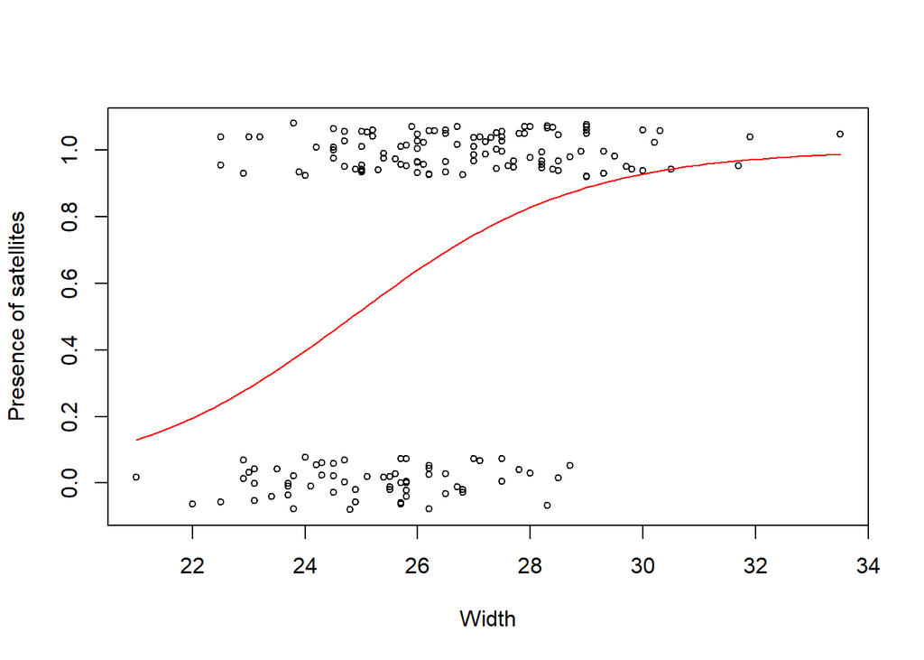

```r
plot(
  jitter(y, amount = 0.08) ~ width,
  data = Crabs,
  cex = 0.7,
  xlab = "Width",
  ylab = "Presence of satellites"
)

fit_width <- glm(
  y ~ width,
  family = binomial(link = "logit"),
  data = Crabs
)

curve(
  predict(fit_width, data.frame(width = x), type = "response"),
  add = TRUE,
  col = "red"
)
```

```r
summary(fit_width)
```

```
Call:
glm(formula = y ~ width, family = binomial(link = "logit"), data = Crabs)

Coefficients:
            Estimate Std. Error z value Pr(>|z|)
(Intercept) -12.3508     2.6287  -4.698 2.62e-06 ***
width         0.4972     0.1017   4.887 1.02e-06 ***
---
Signif. codes:  0 '***' 0.001 '**' 0.01 '*' 0.05 '.' 0.1 ' ' 1

(Dispersion parameter for binomial family taken to be 1)

    Null deviance: 225.76  on 172  degrees of freedom
Residual deviance: 194.45  on 171  degrees of freedom
AIC: 198.45

Number of Fisher Scoring iterations: 4
```

The fitted logistic regression model is

$$\operatorname{logit}\{\hat\pi(x)\}=-12.351+0.497x,$$

or

$$\hat\pi(x)=\frac{\exp(-12.351+0.497x)}
{1+\exp(-12.351+0.497x)}.$$

```r
predict(fit_width, data.frame(width = 21.0), type = "response")
```

```
       1
0.129096
```

```r
predict(
  fit_width,
  data.frame(width = mean(Crabs$width)),
  type = "response"
)
```

```
        1
0.6738768
```

At width 21.0 cm, the fitted probability is approximately 0.129.

### Statistical Inference for Logistic Regression

A Wald confidence interval for a coefficient is

$$\hat\beta\mathbin{\pm}z_{\alpha/2}SE(\hat\beta).$$

Exponentiating its endpoints gives a confidence interval for $\exp(\beta)$, the multiplicative effect on the odds. A profile likelihood interval contains parameter values that are not rejected by likelihood-ratio tests. It is often more reliable than a Wald interval for small samples, fitted probabilities close to 0 or 1, or data showing separation.

```r
summary(fit_width)$coefficients
```

```
               Estimate Std. Error   z value     Pr(>|z|)
(Intercept) -12.3508177  2.6287179 -4.698419 2.621832e-06
width         0.4972306  0.1017355  4.887482 1.021340e-06
```

```r
confint(fit_width)
```

```
                  2.5 %     97.5 %
(Intercept) -17.8100090 -7.4572470
width         0.3083806  0.7090167
```

```r
car::Anova(fit_width, test.statistic = "LR")
```

|  | LR Chisq | Df | Pr(>Chisq) |
| --- | --- | --- | --- |
| width | 31.30586 | 1 | 2.204134e-08 |

```r
anova(fit_width, test = "LRT")
```

|  | Df | Deviance | Resid. Df | Resid. Dev | Pr(>Chi) |
| --- | --- | --- | --- | --- | --- |
| NULL | NA | NA | 172 | 225.7585 | NA |
| width | 1 | 31.30586 | 171 | 194.4527 | 2.204134e-08 |

### Fitted Values and Confidence Intervals for Probabilities

A confidence interval for $\pi(x)$ can be obtained by first constructing a confidence interval for the linear predictor $\eta(x)=\alpha+\beta x$ and then applying the inverse-logit function. The transformed endpoints always lie between 0 and 1.

```r
linear_predictor <- predict(fit_width, se.fit = TRUE)
lower_linear <- linear_predictor$fit - qnorm(0.975) * linear_predictor$se.fit
upper_linear <- linear_predictor$fit + qnorm(0.975) * linear_predictor$se.fit

probability_results <- data.frame(
  width = Crabs$width,
  fitted_probability = fitted(fit_width),
  lower = plogis(lower_linear),
  upper = plogis(upper_linear)
)
probability_results
```

|  | width | fitted_probability | lower | upper |
| --- | --- | --- | --- | --- |
| 1 | 28.3 | 0.8482329 | 0.75285206 | 0.9111481 |
| 2 | 22.5 | 0.2380991 | 0.12998572 | 0.3952793 |
| 3 | 26.0 | 0.6404177 | 0.55808945 | 0.7152343 |
| 4 | 24.8 | 0.4951254 | 0.39825664 | 0.5923614 |
| 5 | 26.0 | 0.6404177 | 0.55808945 | 0.7152343 |
| 6 | 23.8 | 0.3736172 | 0.26139450 | 0.5013184 |
| 7 | 26.5 | 0.6954646 | 0.61205440 | 0.7677464 |
| 8 | 24.7 | 0.4827014 | 0.38396371 | 0.5828085 |
| 9 | 23.7 | 0.3620557 | 0.24904519 | 0.4927019 |
| 10 | 25.6 | 0.5934595 | 0.50883649 | 0.6728758 |

[output cut: 163 more lines]

#### Plotting

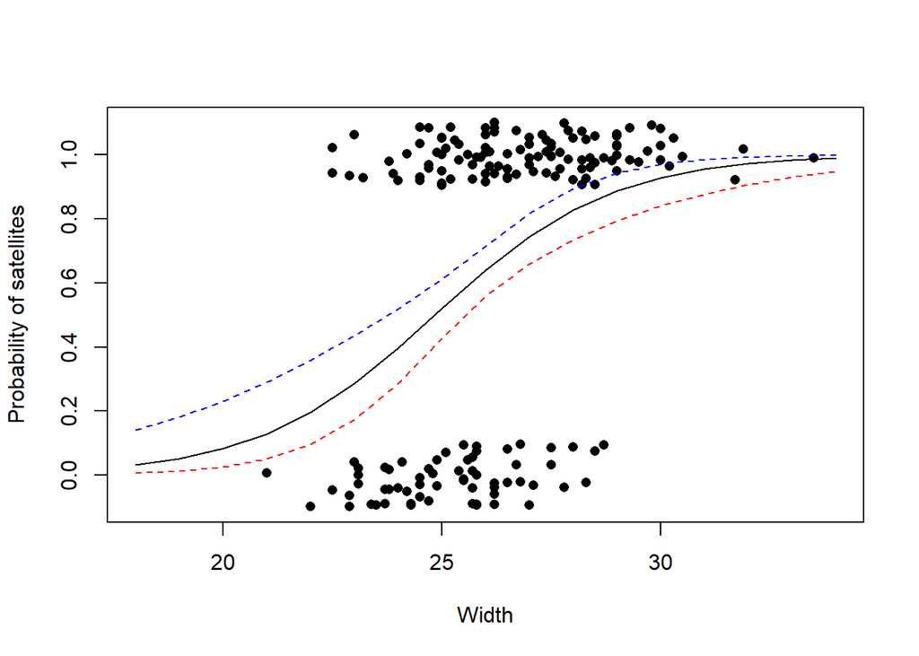

```r
plot(
  jitter(y, amount = 0.1) ~ width,
  data = Crabs,
  xlim = c(18, 34),
  pch = 16,
  xlab = "Width",
  ylab = "Probability of satellites"
)

plot_data <- data.frame(width = 18:34)
plot_predictor <- predict(fit_width, newdata = plot_data, se.fit = TRUE)
plot_lower <- plot_predictor$fit - qnorm(0.975) * plot_predictor$se.fit
plot_upper <- plot_predictor$fit + qnorm(0.975) * plot_predictor$se.fit

lines(plot_data$width, plogis(plot_predictor$fit))
lines(plot_data$width, plogis(plot_lower), col = "red", lty = 2)
lines(plot_data$width, plogis(plot_upper), col = "blue", lty = 2)
```

### Logistic Regression with Categorical Explanatory Variables

A categorical explanatory variable is represented by indicator variables relative to a reference category. Each coefficient is a difference in log odds between a category and the reference category, controlling for the other variables. Exponentiating the coefficient gives a conditional odds ratio. The factor levels and reference categories should be checked before interpreting the coefficients.

#### Example: Survey about Marijuana Use

The response is whether a student had ever used marijuana. The explanatory variables are gender and race.

```r
Marijuana <- read.table(
  "https://raw.githubusercontent.com/alanagresti/categorical-data/master/Marijuana.dat",
  header = TRUE
)
Marijuana$gender <- factor(Marijuana$gender, levels = c("female", "male"))
Marijuana$race <- factor(Marijuana$race, levels = c("other", "white"))
Marijuana
```

| race | gender | yes | no |
| --- | --- | --- | --- |
| white | female | 420 | 620 |
| white | male | 483 | 579 |
| other | female | 25 | 55 |
| other | male | 32 | 62 |

```r
fit_marijuana <- glm(
  yes / (yes + no) ~ gender + race,
  weights = yes + no,
  family = binomial(link = "logit"),
  data = Marijuana
)
summary(fit_marijuana)
```

```
Call:
glm(formula = yes/(yes + no) ~ gender + race, family = binomial(link = "logit"),
    data = Marijuana, weights = yes + no)

Coefficients:
            Estimate Std. Error z value Pr(>|z|)
(Intercept) -0.83035    0.16854  -4.927 8.37e-07 ***
gendermale   0.20261    0.08519   2.378  0.01739 *
racewhite    0.44374    0.16766   2.647  0.00813 **
---
Signif. codes:  0 '***' 0.001 '**' 0.01 '*' 0.05 '.' 0.1 ' ' 1

(Dispersion parameter for binomial family taken to be 1)

    Null deviance: 12.752784  on 3  degrees of freedom
Residual deviance:  0.057982  on 1  degrees of freedom
AIC: 30.414

Number of Fisher Scoring iterations: 3
```

The estimated coefficient for males relative to females is approximately 0.203, and the estimated coefficient for whites relative to others is approximately 0.444.

```r
car::Anova(fit_marijuana, test.statistic = "LR")
```

|  | LR Chisq | Df | Pr(>Chisq) |
| --- | --- | --- | --- |
| gender | 5.666175 | 1 | 0.017295125 |
| race | 7.277030 | 1 | 0.006984192 |

The likelihood-ratio test for the gender effect and the corresponding Wald test both provide evidence that marijuana use differs by gender after controlling for race.

### Multiple Logistic Regression

For predictors $x_1,\ldots,x_p$,

$$\operatorname{logit}\{\pi(x)\}
=\alpha+\beta_1x_1+\cdots+\beta_px_p.$$

The coefficient $\beta_j$ describes the effect of $x_j$ on the log odds of $Y=1$, controlling for the other predictors. Strong association among explanatory variables can increase the standard errors of individual coefficients. A main-effects model without interaction assumes that a conditional odds ratio does not change across levels of the other predictors.

#### Example: Horseshoe Crabs

The predictors are shell width and color, where color has four categories: medium light, medium, medium dark, and dark.

```r
Crabs$color_factor <- factor(
  Crabs$color,
  levels = 1:4,
  labels = c("medium light", "medium", "medium dark", "dark")
)

fit_color_factor <- glm(
  y ~ width + color_factor,
  family = binomial(link = "logit"),
  data = Crabs
)
summary(fit_color_factor)
```

```
Call:
glm(formula = y ~ width + color_factor, family = binomial(link = "logit"),
    data = Crabs)

Coefficients:
                         Estimate Std. Error z value Pr(>|z|)
(Intercept)             -11.38519    2.87346  -3.962 7.43e-05 ***
width                     0.46796    0.10554   4.434 9.26e-06 ***
color_factormedium        0.07242    0.73989   0.098    0.922
color_factormedium dark  -0.22380    0.77708  -0.288    0.773
color_factordark         -1.32992    0.85252  -1.560    0.119
---
Signif. codes:  0 '***' 0.001 '**' 0.01 '*' 0.05 '.' 0.1 ' ' 1

(Dispersion parameter for binomial family taken to be 1)

    Null deviance: 225.76  on 172  degrees of freedom
Residual deviance: 187.46  on 168  degrees of freedom
AIC: 197.46

Number of Fisher Scoring iterations: 4
```

With medium light as the reference color, the fitted equation is approximately

$$\operatorname{logit}\{\hat P(Y=1)\}
=-11.385+0.468x+0.072c_2-0.224c_3-1.330c_4.$$

At width 26.3 cm, the fitted probabilities are approximately 0.715 for a medium-light crab and 0.399 for a dark crab.

### Model Comparison

Likelihood-ratio comparisons apply to nested models. The test statistic is the difference in deviances, and its degrees of freedom equal the difference in the numbers of model parameters.

To test whether color contributes after controlling for width,

$$H_0:\beta_2=\beta_3=\beta_4=0.$$

```r
fit_width_only <- glm(
  y ~ width,
  family = binomial(link = "logit"),
  data = Crabs
)

anova(fit_width_only, fit_color_factor, test = "LRT")
```

|  | Resid. Df | Resid. Dev | Df | Deviance | Pr(>Chi) |
| --- | --- | --- | --- | --- | --- |
| 1 | 171 | 194.4527 | NA | NA | NA |
| 2 | 168 | 187.4570 | 3 | 6.995631 | 0.07203714 |

The likelihood-ratio statistic is approximately 6.99 with three degrees of freedom.

#### Variation 1: Treating Color as Quantitative

Using the scores $c=(1,2,3,4)$ assumes a constant change in the log odds for each one-category increase in color darkness. Treating color as a factor does not impose this restriction but uses more parameters.

```r
fit_color_score <- glm(
  y ~ width + color,
  family = binomial(link = "logit"),
  data = Crabs
)

summary(fit_color_score)
```

```
Call:
glm(formula = y ~ width + color, family = binomial(link = "logit"),
    data = Crabs)

Coefficients:
            Estimate Std. Error z value Pr(>|z|)
(Intercept) -10.0708     2.8068  -3.588 0.000333 ***
width         0.4583     0.1040   4.406 1.05e-05 ***
color        -0.5090     0.2237  -2.276 0.022860 *
---
Signif. codes:  0 '***' 0.001 '**' 0.01 '*' 0.05 '.' 0.1 ' ' 1

(Dispersion parameter for binomial family taken to be 1)

    Null deviance: 225.76  on 172  degrees of freedom
Residual deviance: 189.12  on 170  degrees of freedom
AIC: 195.12

Number of Fisher Scoring iterations: 4
```

```r
anova(fit_color_score, fit_color_factor, test = "LRT")
```

|  | Resid. Df | Resid. Dev | Df | Deviance | Pr(>Chi) |
| --- | --- | --- | --- | --- | --- |
| 1 | 170 | 189.1212 | NA | NA | NA |
| 2 | 168 | 187.4570 | 2 | 1.664145 | 0.4351466 |

The estimated color coefficient is approximately $-0.509$. At a fixed width, each one-category increase in darkness multiplies the estimated odds of having a satellite by $\exp(-0.509)=0.60$. The likelihood-ratio comparison does not indicate important lack of fit from this linear color scoring.

#### Variation 2: Separating Dark Crabs from the Other Colors

Let $c^*=1$ for dark crabs and $c^*=0$ otherwise.

```r
Crabs$dark <- as.integer(Crabs$color == 4)

fit_dark <- glm(
  y ~ width + dark,
  family = binomial(link = "logit"),
  data = Crabs
)

summary(fit_dark)
```

```
Call:
glm(formula = y ~ width + dark, family = binomial(link = "logit"),
    data = Crabs)

Coefficients:
            Estimate Std. Error z value Pr(>|z|)
(Intercept) -11.6790     2.6925  -4.338 1.44e-05 ***
width         0.4782     0.1041   4.592 4.39e-06 ***
dark         -1.3005     0.5259  -2.473   0.0134 *
---
Signif. codes:  0 '***' 0.001 '**' 0.01 '*' 0.05 '.' 0.1 ' ' 1

(Dispersion parameter for binomial family taken to be 1)

    Null deviance: 225.76  on 172  degrees of freedom
Residual deviance: 187.96  on 170  degrees of freedom
AIC: 193.96

Number of Fisher Scoring iterations: 4
```

```r
anova(fit_dark, fit_color_factor, test = "LRT")
```

|  | Resid. Df | Resid. Dev | Df | Deviance | Pr(>Chi) |
| --- | --- | --- | --- | --- | --- |
| 1 | 170 | 187.9579 | NA | NA | NA |
| 2 | 168 | 187.4570 | 2 | 0.5008469 | 0.7784711 |

The likelihood-ratio comparison indicates that this simpler binary color model is also compatible with the factor model.

#### Variation 3: Allowing Interaction

An interaction permits the width effect to differ between dark and non-dark crabs:

$$\operatorname{logit}\{P(Y=1)\}
=\alpha+\beta_1x+\beta_2c^*+\beta_{12}xc^*.$$

The width slope is $\beta_1$ for non-dark crabs and $\beta_1+\beta_{12}$ for dark crabs.

```r
fit_interaction <- glm(
  y ~ width * dark,
  family = binomial(link = "logit"),
  data = Crabs
)

summary(fit_interaction)
```

```
Call:
glm(formula = y ~ width * dark, family = binomial(link = "logit"),
    data = Crabs)

Coefficients:
            Estimate Std. Error z value Pr(>|z|)
(Intercept) -12.8117     2.9576  -4.332 1.48e-05 ***
width         0.5222     0.1146   4.556 5.21e-06 ***
dark          6.9578     7.3182   0.951    0.342
width:dark   -0.3217     0.2857  -1.126    0.260
---
Signif. codes:  0 '***' 0.001 '**' 0.01 '*' 0.05 '.' 0.1 ' ' 1

(Dispersion parameter for binomial family taken to be 1)

    Null deviance: 225.76  on 172  degrees of freedom
Residual deviance: 186.79  on 169  degrees of freedom
AIC: 194.79

Number of Fisher Scoring iterations: 4
```

```r
anova(fit_dark, fit_interaction, test = "LRT")
```

|  | Resid. Df | Resid. Dev | Df | Deviance | Pr(>Chi) |
| --- | --- | --- | --- | --- | --- |
| 1 | 170 | 187.9579 | NA | NA | NA |
| 2 | 169 | 186.7864 | 1 | 1.171525 | 0.2790881 |

The evidence of interaction is weak, so the main-effects model is easier to interpret. The two nonnested simplified color models can be compared using AIC.

```r
AIC(fit_color_score, fit_dark)
```

|  | df | AIC |
| --- | --- | --- |
| fit_color_score | 3 | 195.1212 |
| fit_dark | 3 | 193.9579 |

### Summarizing Effects in Logistic Regression

Odds ratios provide a compact summary, but changes in fitted probabilities can be easier to understand. For a quantitative predictor, fitted probabilities can be compared at meaningful values such as the lower and upper quartiles. For a binary predictor, probabilities can be compared between its two categories while holding the other predictors fixed.

#### Probability-Based Interpretation

```r
predict(
  fit_dark,
  data.frame(dark = 1, width = mean(Crabs$width)),
  type = "response"
)
```

```
        1
0.4006293
```

```r
predict(
  fit_dark,
  data.frame(dark = 0, width = mean(Crabs$width)),
  type = "response"
)
```

```
        1
0.7104701
```

```r
predict(
  fit_dark,
  data.frame(
    dark = mean(Crabs$dark),
    width = quantile(Crabs$width, probs = c(0.25, 0.75))
  ),
  type = "response"
)
```

```
      25%       75%
0.5158264 0.8025564
```

#### Marginal Effects and Their Average

For logistic regression, the change in probability from a change in a predictor depends on the current predictor values. An average marginal effect averages the observation-specific changes over the sample. It is different from evaluating the effect after setting every predictor equal to its sample mean.

```r
mfx::logitmfx(
  y ~ width + dark,
  data = Crabs,
  atmean = FALSE
)
```

```
Call:
mfx::logitmfx(formula = y ~ width + dark, data = Crabs, atmean = FALSE)

Marginal Effects:
          dF/dx Std. Err.       z     P>|z|
width  0.087483  0.024472  3.5748 0.0003504 ***
dark  -0.261420  0.105690 -2.4735 0.0133809 *
---
Signif. codes:  0 '***' 0.001 '**' 0.01 '*' 0.05 '.' 0.1 ' ' 1

dF/dx is for discrete change for the following variables:

[1] "dark"
```

The width result is the average rate of change in the fitted probability for a 1 cm increase in width. The result for `dark` is the average discrete change from a non-dark crab to a dark crab at the observed width values.

### Summarizing Predictive Power

Classification accuracy depends on the selected cutoff and the prevalence of the event. The ROC curve displays sensitivity and specificity over possible cutoffs, and the area under the curve summarizes discrimination.

#### Classification Table

```r
cutoff <- mean(Crabs$y)
predicted_class <- as.integer(fitted(fit_dark) > cutoff)
xtabs(~ observed + predicted, data = data.frame(
  observed = Crabs$y,
  predicted = predicted_class
))
```

```
        predicted
observed  0  1
       0 41 21
       1 33 78
```

#### ROC Curve

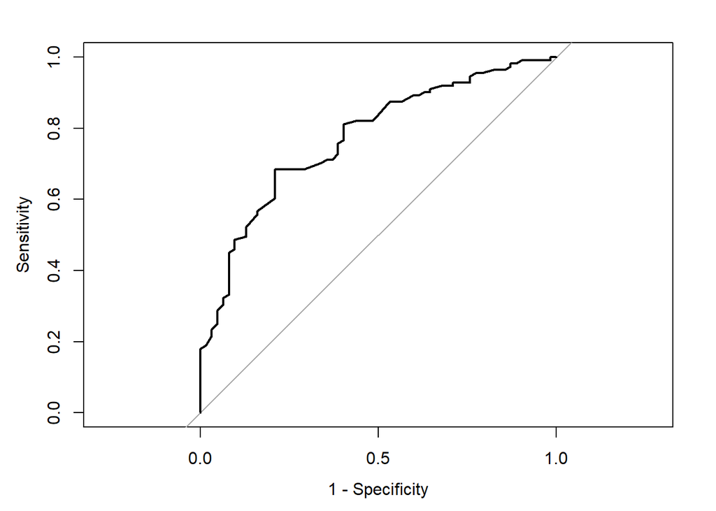

```r
roc_curve <- pROC::roc(
  response = Crabs$y,
  predictor = fitted(fit_dark),
  quiet = TRUE
)

plot(roc_curve, legacy.axes = TRUE)
```

```r
pROC::auc(roc_curve)
```

```
Area under the curve: 0.772
```

#### Multiple Correlation

```r
cor(Crabs$y, fitted(fit_dark))
```

```
[1] 0.4469688
```